# Personnes_agees

RESURAL (JcB)

Date: 03/01/2015

Temps de travail: 2 x 8 heures

Contacts: Dr Schieber, Dr Pillay

# Demande

Dans ce cadre, serait-il ainsi possible à travers une requête RPU d’avoir des données concernant :

- le nombre de passages en 2013 et en 2014 (jusqu’au mois de novembre) selon différentes classes d’âge suivantes:
  - entre >= 55 et <65 ans
  - entre >=65 et <75 ans
  - entre >=75 et <85 ans
  - > =85 ans.  
    > en les rapportant au total de passages.
- le mode d’arrivée et l’origine (mais il me semble qu’à travers les RPU, on ne peut avoir l’information origine domicile/EHPAD…?) (selon les classes d’âge ci-dessus si possible)
- leur orientation à l’issue du passage aux urgences (selon les classes d’âge ci-dessus si possible)
- des informations à travers les motifs et/ou les diagnostics (chute/trouble de la marche/trouble de l’équilibre) en regroupant certains codes ?

# Codes CIM 10

## Chutes

Y30 Chute, saut ou précipitation dans le vide, intention non déterminée, chute de la victime d’un niveau à un autre, intention non déterminée

```
Y30.0  Chute au domicile
Y30.1   Chute dans un établissement collectif
Y30.2   Chute dans une institution
Y30.3   Chute dans un lieu de sport
Y30.4   Chute sur la route
Y30.5   Chute, saut ou précipitation dans le vide, intention non déterminée, dans une zone de commerce et de services
Y30.6   Chute, saut ou précipitation dans le vide, intention non déterminée, dans un local industriel et chantier de construction
Y30.7   Chute, saut ou précipitation dans le vide, intention non déterminée, dans une exploitation agricole
Y30.8   Chute
Y30.9   Chute
```

Cet item ne retrouve qu’un seul enregistrement dans la base.

## Traumatisme

```
S00-S09 Lésions traumatiques de la tête
S10-S19 Lésions traumatiques du cou
S20-S29 Lésions traumatiques du thorax
S30-S39 Lésions traumatiques de l'abdomen, des lombes, du rachis lombaire et du bassin
S40-S49 Lésions traumatiques de l'épaule et du bras
S50-S59 Lésions traumatiques du coude et de l'avant-bras
S60-S69 Lésions traumatiques du poignet et de la main
S70-S79 Lésions traumatiques de la hanche et de la cuisse
S80-S89 Lésions traumatiques du genou et de la jambe
S90-S99 Lésions traumatiques de la cheville et du pied
T00-T07 Lésions traumatiques de plusieurs parties du corps
T08-T14 Lésions traumatiques de siège non précisé du tronc, membre ou autre région du corps
```

## Définitions

- Domicile: domicile ou ce qui en tient lieu (voie publique)
- Mutation: hospitalisation dans le même établissement que celui du SU
- Transfert: hospitalisation dans un autre établissement que celui du SU.
- PEO: désigne une prise en charge organisationnelle. Ce code est utilisé lorsque le patient n’est pas destiné aux urgences mais il y transite temporairement (par ex. en attente qu’un lit prévu se libère)
- PEA: désigne une arrivée non programmée aux urgences (cas général)

La FEDORU recommande d’identifier les personnes provenant des EHPAD par l’association MODE ENTREE = 8 (Domicile) + PROVENANCE = 7 (structure médico-sociale). Cependant ce dernier code n’est pas proposé dans la version officielle des RPU.

## Création des sous groupes

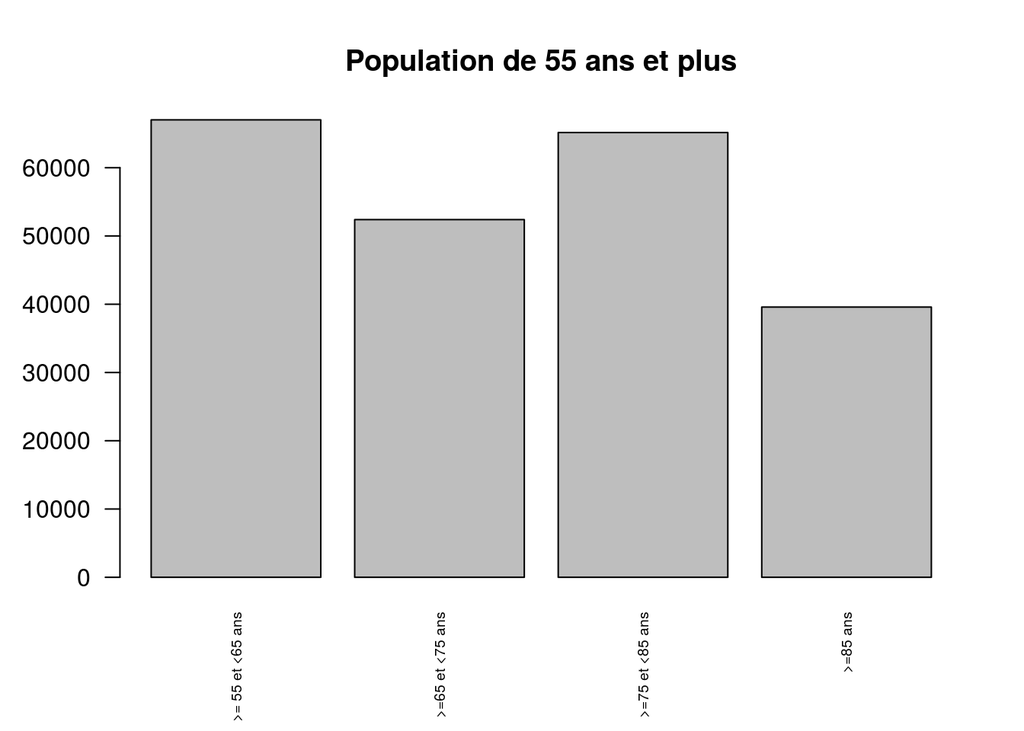

## Résultats

- Date de début: 2013-01-01
- Date de fin: 2014-12-31
- Effectif total: 760806 RPU.
- Nombre de RPU agés de 55 ans ou plus: 231305 (30.4 %)

#### Complétude des données

Pourcentage de RPU renseignés selon l’item:

- MODE ENTREE: 92 %
- PROVENANCE : 55 %
- MODE SORTIE: 82 %
- DESTINATION: 40 %

```
            >= 55 et <65 ans >=65 et <75 ans >=75 et <85 ans >=85 ans
effectif            67010.00        52396.00        65155.00 39585.00
% effectif             28.97           22.65           28.17    17.11
% total RPU             8.81            6.89            8.56     5.20
```

## Selon le MODE_ENTREE et la PROVENANCE

```
## MODE D'ENTREE
##  Domicile  Mutation Transfert
##    205474      2783      4031
```

```
##                   MODE ENTREE
## AGE                Domicile Mutation Transfert
##   >= 55 et <65 ans    60331      591       632
##   >=65 et <75 ans     47058      585       642
##   >=75 et <85 ans     57420      954      1288
##   >=85 ans            34209      602      1403
```

```
## PROVENANCE
##    MCO    SSR    SLD    PSY    PEA    PEO
##   8209    114     31     58 100373  17882
```

```
##                   PROVENANCE
## AGE                  MCO   SSR   SLD   PSY   PEA   PEO
##   >= 55 et <65 ans  1587    10     0    24 31523  5772
##   >=65 et <75 ans   1491    15     4    15 23252  4555
##   >=75 et <85 ans   2711    44     8    15 26837  4703
##   >=85 ans          2256    44    19     1 15194  2285
```

## Mode de sortie (par classes d’age)

```
MODE DE SORTIE
 Mutation Transfert  Domicile     Décès
    87595      5410     97521         1
```

```
DESTINATION
  MCO   SSR   SLD   PSY   HAD   HMS
91955   175    46   692     9    24
```

```
ORIENTATION
 CHIR FUGUE   HDT    HO   MED  OBST   PSA   REA   REO    SC  SCAM    SI
10634   101    65    21 24483    33   890  1565   830   984   323  3449
 UHCD
41600
```

```
                  MODE DE SORTIE
AGE                Mutation Transfert Domicile Décès
  >= 55 et <65 ans    17235      1328    37089     0
  >=65 et <75 ans     18518      1157    23646     0
  >=75 et <85 ans     29950      1701    21789     1
  >=85 ans            20425      1091    10667     0
```

```
                  DESTINATION
AGE                  MCO   SSR   SLD   PSY   HAD   HMS
  >= 55 et <65 ans 18241    20     1   288     3     1
  >=65 et <75 ans  19467    28     5   150     1     2
  >=75 et <85 ans  31352    74    11   157     3     6
  >=85 ans         21342    51    28    62     2    15
```

```
                  ORIENTATION
AGE                 CHIR FUGUE   HDT    HO   MED  OBST   PSA   REA   REO
  >= 55 et <65 ans  2612    59    28     8  4085     7   441   443   284
  >=65 et <75 ans   2235    21    14     4  5060     7   225   443   229
  >=75 et <85 ans   3287    13    12     7  8870    17   138   501   197
  >=85 ans          2231     1     7     1  6164     2    37   139    84
  Sum              10365    94    61    20 24179    33   841  1526   794
                  ORIENTATION
AGE                   SC  SCAM    SI  UHCD   Sum
  >= 55 et <65 ans   232   138   724  8419 17480
  >=65 et <75 ans    228    96   887  8686 18135
  >=75 et <85 ans    312    54  1212 13763 28383
  >=85 ans           193    20   564 10002 19445
  Sum                965   308  3387 40870 83443
```

# Analyse des codes CIM10

```
##    S600    S601    S602 S602 02    S607    S608    S609
##     256      38     657       1       3      30      56
```

## Merging avec le fichier des recours de l’ORUMIP

Le fichier de recours de l’ORUMIP est chargé sous le nom de **reg**.

La version 2014 du fichier de recours comporte 2158 lignes et 13 colonnes:

```
 [1] "CIM10"                            "Code.Type.Urgences"
 [3] "Libéllé.Type.Urgences"            "Code.Discipline...Topographie"
 [5] "Libellé.Discipline...Topographie" "Code.Type.Pathologie"
 [7] "Libéllé.Type.de.Pathologie"       "X"
 [9] "X.1"                              "X.2"
[11] "X.3"                              "X.4"
[13] "X.5"
```

Les colonnes 9 à 13 sont des compléments pas indispensables.

La colonne 1 (CIM10) comprend des codes de 3 à 6 caractèes:

```r
a<- sapply(as.character(reg$CIM10), nchar)
table(a)
```

```
## a
##    3    4    5    6
##  122 1619  398   19
```

## Par type d’urgences

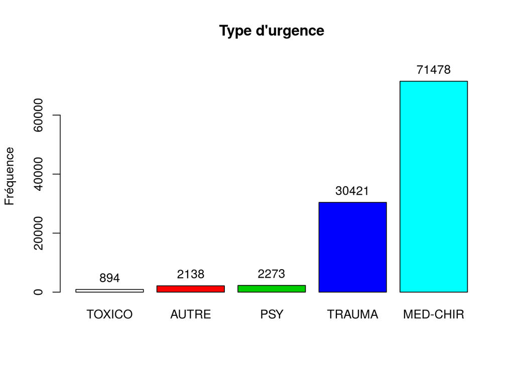

```
## greg$Code.Type.Urgences :
##          Frequency Percent Cum. percent
## TOXICO         894     0.8          0.8
## AUTRE         2138     2.0          2.8
## PSY           2273     2.1          4.9
## TRAUMA       30421    28.4         33.3
## MED-CHIR     71478    66.7        100.0
##   Total     107204   100.0        100.0
```

```
##
##                    AUTRE MED-CHIR   PSY TOXICO TRAUMA
##   >= 55 et <65 ans   779    18018   964    392  10072
##   >=65 et <75 ans    535    16382   514    193   6381
##   >=75 et <85 ans    501    22128   471    177   7487
##   >=85 ans           236    13189   182     70   5224
```

## Traumatologie

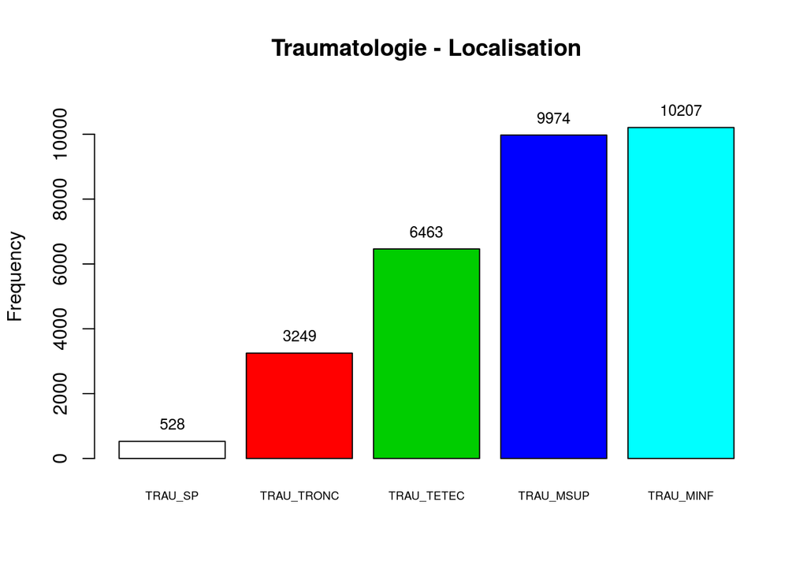

```
## factor(gtrau$Code.Discipline...Topographie) :
##            Frequency Percent Cum. percent
## TRAU_SP          528     1.7          1.7
## TRAU_TRONC      3249    10.7         12.4
## TRAU_TETEC      6463    21.2         33.7
## TRAU_MSUP       9974    32.8         66.4
## TRAU_MINF      10207    33.6        100.0
##   Total        30421   100.0        100.0
```

```
##
##                    TRAU_MINF TRAU_MSUP TRAU_SP TRAU_TETEC TRAU_TRONC
##   >= 55 et <65 ans      3249      3851     198       1785        989
##   >=65 et <75 ans       2054      2266      97       1251        713
##   >=75 et <85 ans       2529      2128     130       1842        858
##   >=85 ans              1953      1253      80       1364        574
```

# Demande 2: 7/01/2014

Dans le cadre de l’évaluation des CPOM des établissements, mais également en lien avec le travail qui s’initie en interne concernant la prise en charge de la personne âgée, nous souhaiterions pouvoir disposer des données par établissement concernant:

- le nombre de primo passages, et la proportion des patients de 75 ans et plus, en incluant les données de l’année 2014 (en précisant le niveau d’exhaustivité atteint dans la base 2014 à ce jour de la requête).
- la moyenne/médiane des temps de passages pour tout âge et pour les 75 ans et plus.

En y incluant les Diaconesses et la clinique Roosevelt, et des totaux par territoires de santé et pour la région.

Ci-joint un tableau pour clarifier la demande, avec certaines données déjà remplies à partir de la dernière version du rapport 2013.

Avez-vous d’ores et déjà des éléments d’explication (liés au codage notamment) au regard des temps de passage très hétérogènes d’une SU à l’autre?

L’échéance souhaitée est le vendredi 16 janvier. Je vous remercie par avance,

## nombre de primo passages, et la proportion des patients de 75 ans et plus

```
   Min. 1st Qu.  Median    Mean 3rd Qu.    Max.    NA's
  75.00   79.00   83.00   83.59   88.00  120.00      14
```

- nombre total de RPU (2013-2014): 760806
- nombre de patients de 75 ans et plus sur la période: 110356
- proportion de 75 ans: 14.51 %.
- exhaustivité pour l’age: 100

## Moyenne/médiane des temps de passages pour tout âge et pour les 75 ans et plus.

#### On sélectionne tous les enregistrements dont heure entréé et sortie ne sont pas NA

```
[1] "nombre de RPU compris entre 0 minutes et 48 heures"
```

```
[1] 687970
```

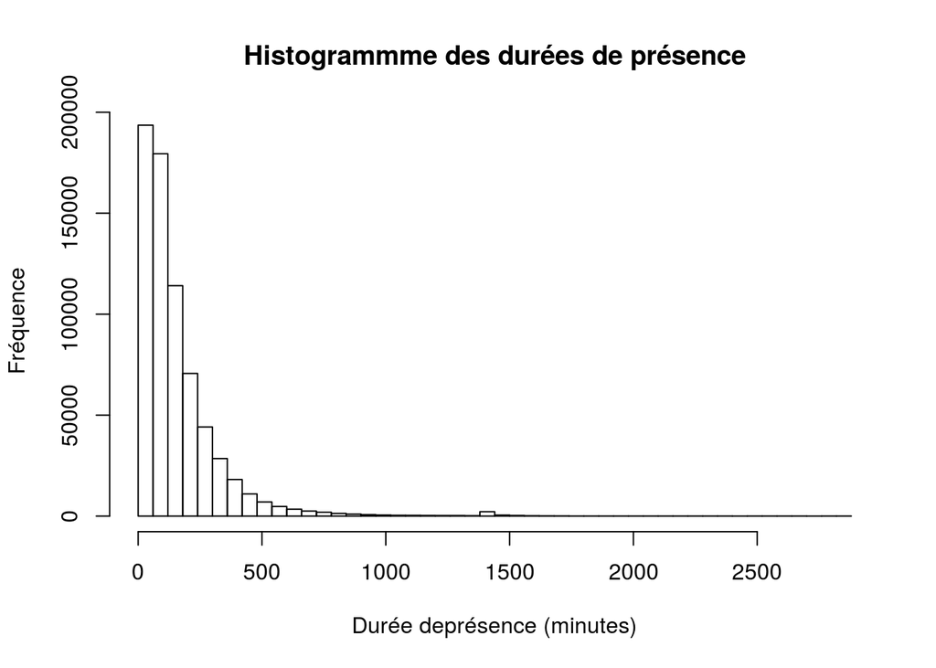

```
[1] "Résumé du groupe 48 heures:"
```

```
   Min. 1st Qu.  Median    Mean 3rd Qu.    Max.
    0.0    55.0   109.0   157.7   202.0  2880.0
```

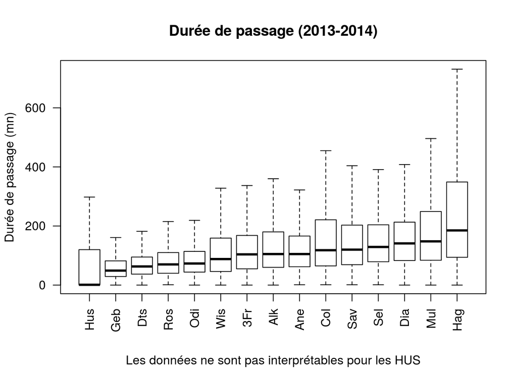

## Même opération pour les plus de 74 ans

Dataframe (dp) avec heure d’entée, de sortie et **age > 74 ans**. L’exhaustivité est > 99%, 14 données sont manquantes

```
[1] "exhaustivité des heures de sortie:"
```

```
[1] 0.999854
```

```
[1] "exhaustivité des heures d'entrée:"
```

```
[1] 0.999854
```

```
[1] "nombre d'heures dentrée manquantes:"
```

```
[1] 14
```

```
[1] "nombre d'heures de sortie manquantes:"
```

```
[1] 14
```

```
[1] "nombre de RPU dont la durée est exploitable"
```

```
[1] 95886
```

```
[1] "Résumé des durées de passage en minutes"
```

```
   Min. 1st Qu.  Median    Mean 3rd Qu.    Max.    NA's
    0.0    67.0   180.0   218.1   304.0  5233.0      14
```

```
[1] "résumé des durées de passage (en mn) de moins de 48 heures"
```

```
   Min. 1st Qu.  Median    Mean 3rd Qu.    Max.    NA's
    0.0    67.0   180.0   217.4   304.0  2880.0      14
```

```
[1] "Nombre de RPU dont age > 74 ans et la durée de présence =< 48h:"
```

```
[1] 95866
```

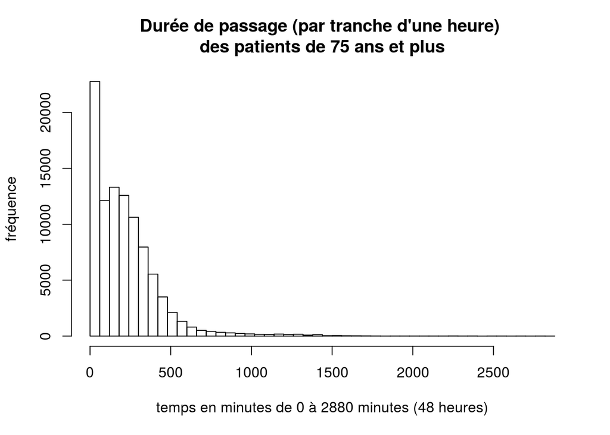

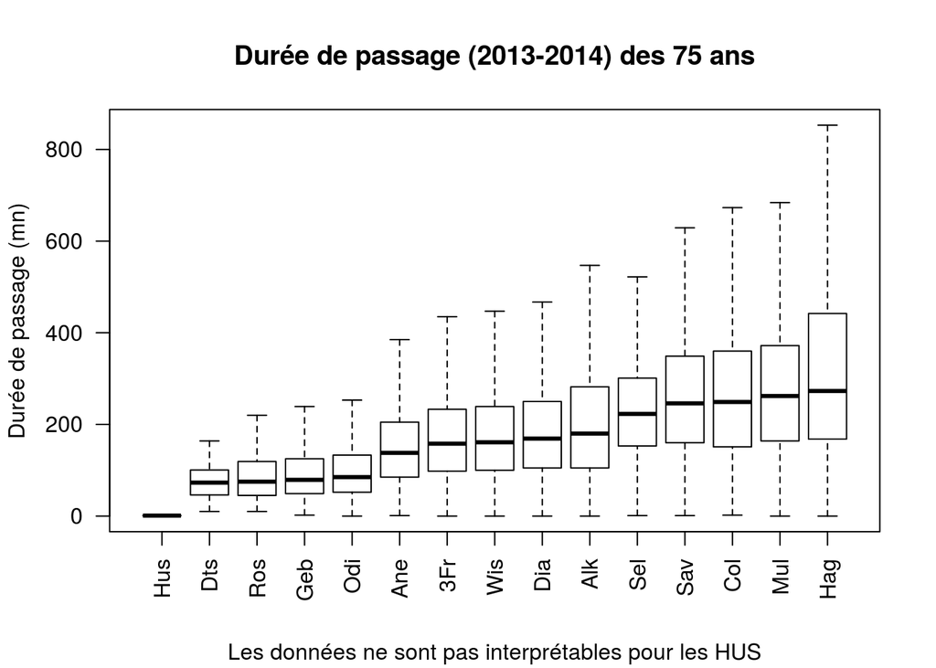

162 données sont incomplètes (il manque l’heure). Correspondent toutes à Wissembourg et au mois de novembre 2014 où a eu lieu un problème de transmission.

Pour les patients agés de 75 ans ou plus:

- moyenne: 217.4 minutes
- écart-type: NA minutes
- médiane: 180 minutes

## Relation durée de passage / nombre de passages

### Avec les HUS

```
##               np75  mean.p75
## np75     1.0000000 0.3657578
## mean.p75 0.3657578 1.0000000
```

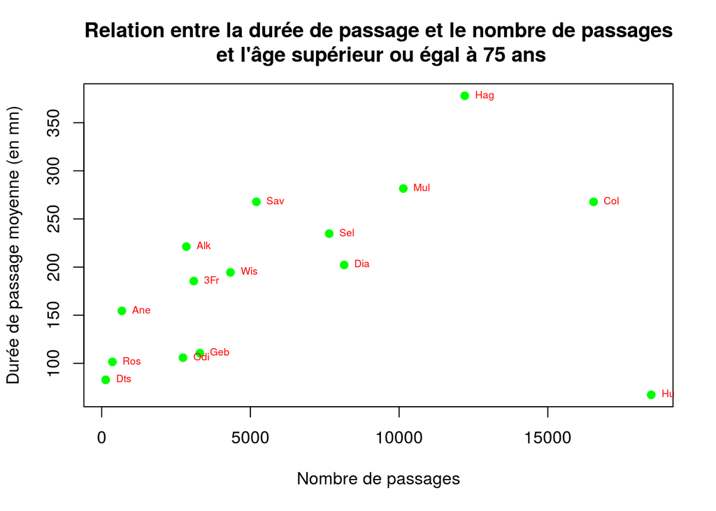

### Sans les HUS

Les HUS ne remontent correctement les durées de passages que depuis novembre 2014. Auparavant plus de la moitié des durées sont égales à 1 minute, ce qui fausse les résultats. La même estimation est refaite en retirant les HUS.

```
Call:
lm(formula = mean.p75[-9] ~ np75[-9])

Residuals:
    Min      1Q  Median      3Q     Max
-82.136 -40.174   9.102  21.146  87.379

Coefficients:
             Estimate Std. Error t value Pr(>|t|)
(Intercept) 1.236e+02  2.225e+01   5.556 0.000125 ***
np75[-9]    1.368e-02  3.075e-03   4.451 0.000792 ***
---
Signif. codes:  0 '***' 0.001 '**' 0.01 '*' 0.05 '.' 0.1 ' ' 1

Residual standard error: 53.71 on 12 degrees of freedom
Multiple R-squared:  0.6228,    Adjusted R-squared:  0.5913
F-statistic: 19.81 on 1 and 12 DF,  p-value: 0.0007917
```

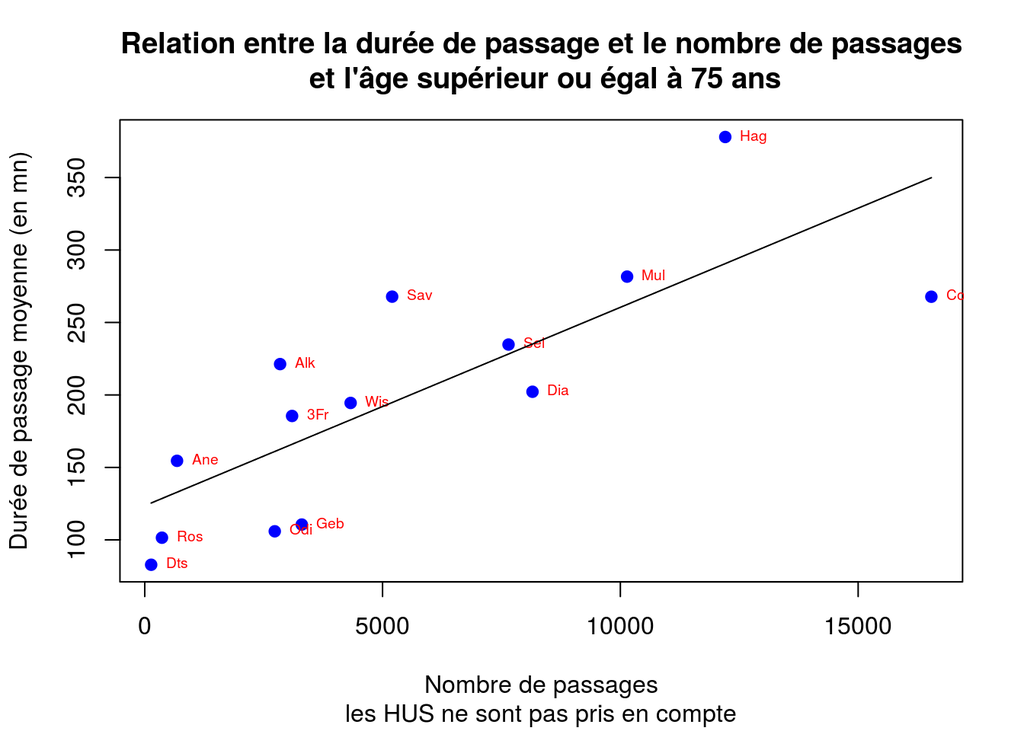

Il existe ue relation linéaire entre la durée de passage et le nombre de passage. Cette liaison est statistiquement significative. Dans ce modèle, le nombre de passages explique environ 60% du temps de passage aux urgences. Il faudrait standardiser sur le nombre de passages pour comparer les durées de passage.

## Par territoire de santé

On crée une colonne supplémentaire pour les territoires de santé

```r
dp.tot$TERRITOIRE[dp.tot$FINESS %in% c("Wis","Sav","Hag")] <- "T1"
dp.tot$TERRITOIRE[dp.tot$FINESS %in% c("Hus","Odi","Ane","Dts")] <- "T2"
dp.tot$TERRITOIRE[dp.tot$FINESS %in% c("Sel","Col","Geb")] <- "T3"
dp.tot$TERRITOIRE[dp.tot$FINESS %in% c("Mul","3Fr","Alk","Ros","Dia")] <- "T4"
```

Nettoyage de dp.tot:

- supprimer les valeurs négatives
- supprimer les durées > 48 heures
- supprimer les NA

```r
dp.tot2 <- dp.tot[dp.tot$DUREE >= 0 & dp.tot$DUREE < H48+1 & !is.na(dp.tot$DUREE),]
```

Résultats sur données nettoyées:

- durée moyenne de passage par territoire

```
      T1       T2       T3       T4
211.0402 108.8501 148.7545 166.0941
```

- écart-type

```
      T1       T2       T3       T4
227.6488 213.0044 135.8781 148.8430
```

- médiane

```
 T1  T2  T3  T4
138  53 108 131
```

- boxplot durée de passage par territoire

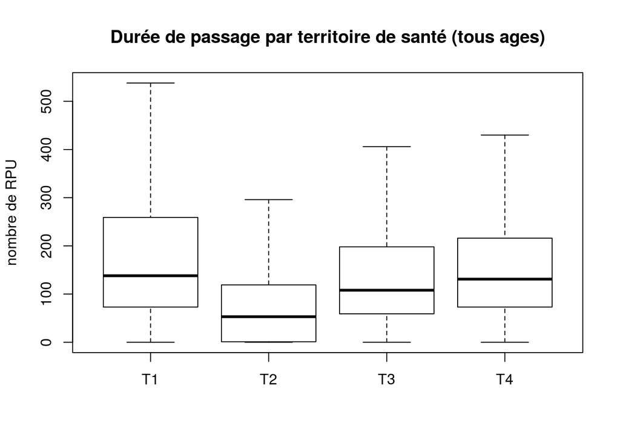

- territoire 1: tiré vers le haut par Haguenau
- territoire 2: tiré vers le bas par les HUS qui représentent le nombre le plus élevé de RPU du territoire et celui où les durées de passage sont fausses jusqu’en novembre 2014.

Pour avoir une meilleure idée, on refait les mêmes calculs sur les mois de novembre et décembre 2014 qui sont les plus exacts en terme de remontée des RPU. On appelle dp.tot3 ce dataframe:

- durée moyenne de passage par territoire en novembre-déembre 2014

```
      T1       T2       T3       T4
161.4098 167.3956 153.7590 176.3113
```

- ecart-type

```
      T1       T2       T3       T4
138.7090 186.6029 140.3062 155.0814
```

- médiane

```
 T1  T2  T3  T4
123 105 111 139
```

- box plot

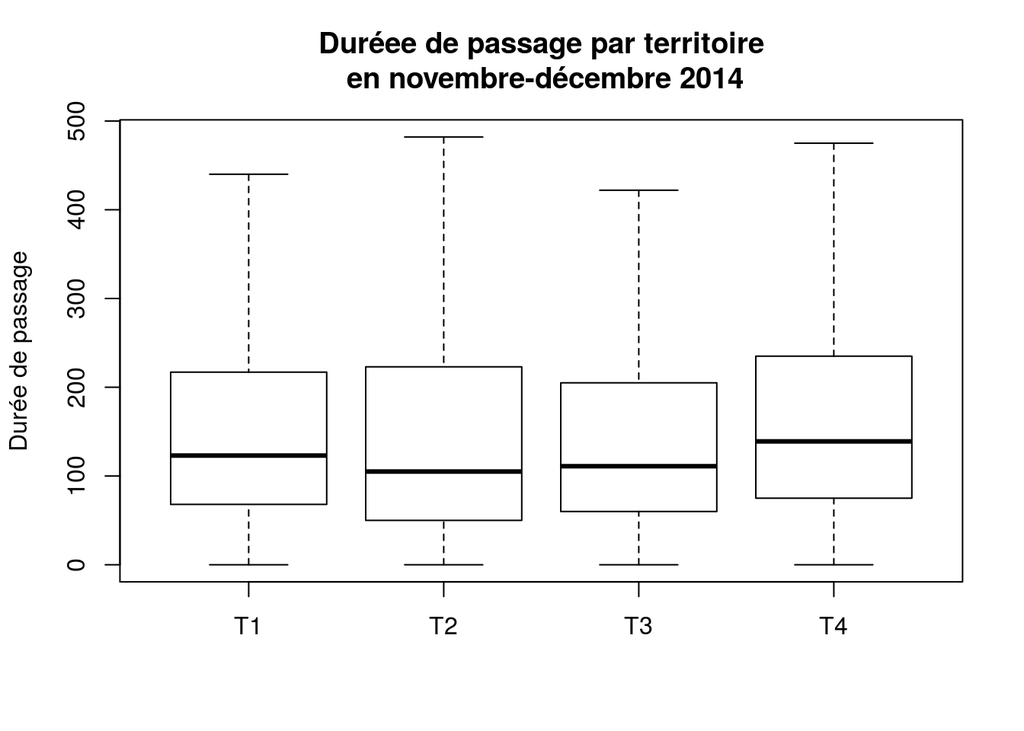

Analyse de la variance: existe t il une durée de passage différente selon le territoire ?

```
                      Df    Sum Sq Mean Sq F value Pr(>F)
dp.tot3$TERRITOIRE     3 4.774e+06 1591193   61.66 <2e-16 ***
Residuals          72669 1.875e+09   25807
---
Signif. codes:  0 '***' 0.001 '**' 0.01 '*' 0.05 '.' 0.1 ' ' 1
```

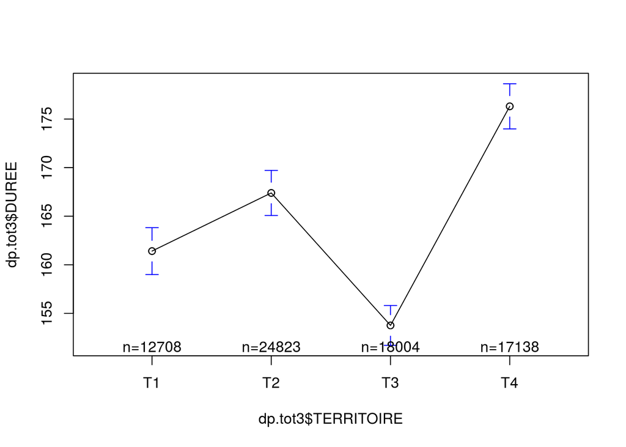

La normalité n’étant pas sûre, les résultats de l’Anova ne le sont pas non plus. On vérifie avec un test non paramétrique (Kruskall-Wallis):

```
    Kruskal-Wallis rank sum test

data:  dp.tot3$DUREE by as.factor(dp.tot3$TERRITOIRE)
Kruskal-Wallis chi-squared = 639.2595, df = 3, p-value < 2.2e-16
```

Il existe bien une did=fférence entre les territoires.

#### Sur cette même période (novembre-décembre 2014) on s’intéresse au plus de 74 ans.

dp3.75 = tous les RPU créés en novembre-décembre 2014 dont la durée de présence est comprise entre 0 mn et 48 heures

```
[1] 8969
```

```
   Min. 1st Qu.  Median    Mean 3rd Qu.    Max.    NA's
    0.0   131.8   233.0   264.0   361.0  2190.0       1
```

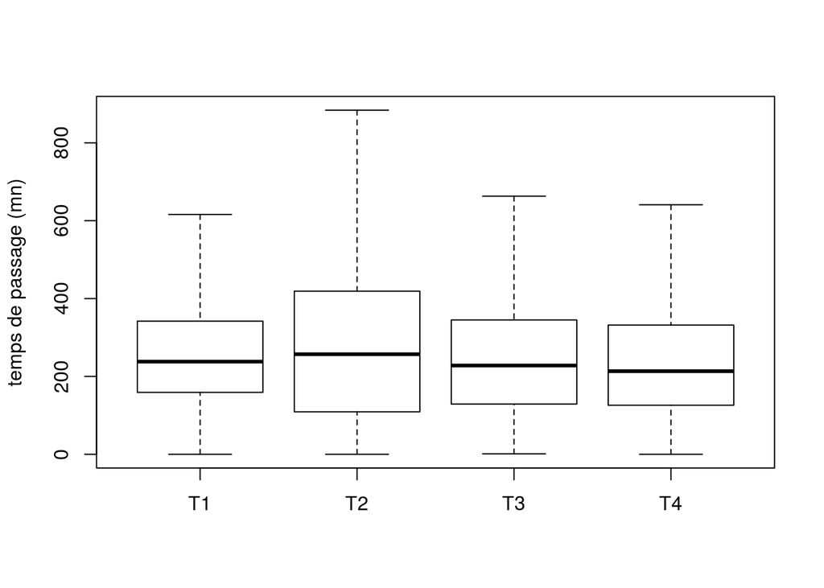

```
                    Df    Sum Sq Mean Sq F value   Pr(>F)
dp3.75$TERRITOIRE    3   2576131  858710   24.65 7.09e-16 ***
Residuals         8964 312318540   34841
---
Signif. codes:  0 '***' 0.001 '**' 0.01 '*' 0.05 '.' 0.1 ' ' 1
1 observation deleted due to missingness
```

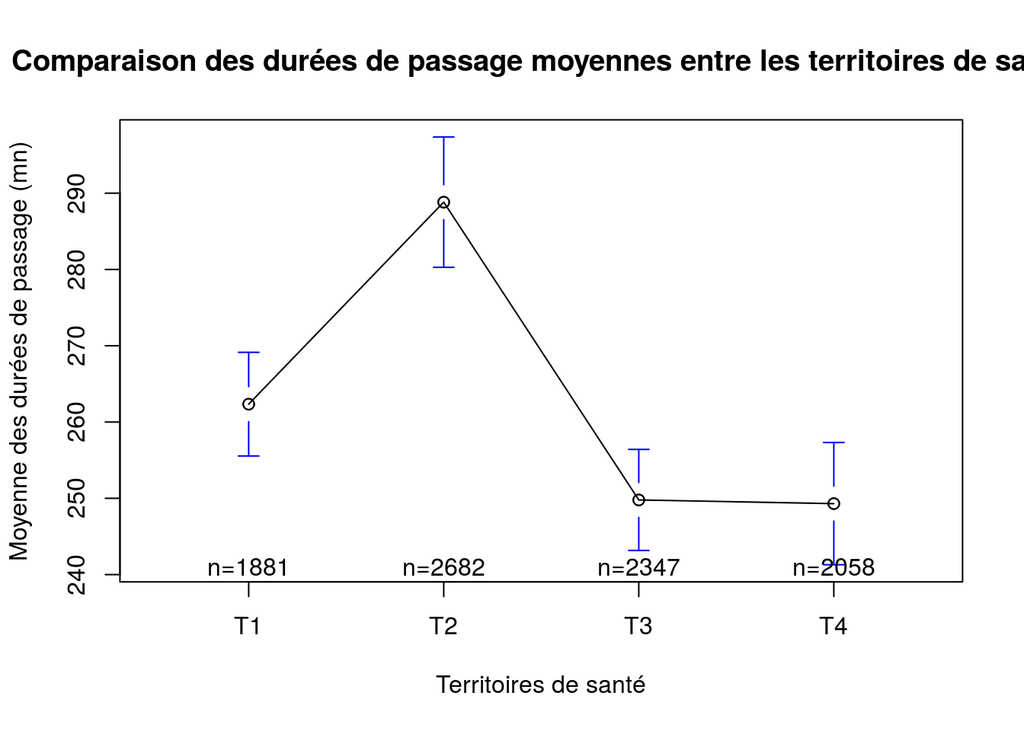

```
  Tukey multiple comparisons of means
    95% family-wise confidence level

Fit: aov(formula = dp3.75$DUREE ~ dp3.75$TERRITOIRE)

$`dp3.75$TERRITOIRE`
             diff       lwr        upr     p adj
T2-T1  26.4782370  12.05375  40.902723 0.0000145
T3-T1 -12.5563629 -27.39915   2.286424 0.1306521
T4-T1 -13.0389068 -28.33832   2.260507 0.1260732
T3-T2 -39.0345998 -52.59129 -25.477906 0.0000000
T4-T2 -39.5171438 -53.57231 -25.461977 0.0000000
T4-T3  -0.4825439 -14.96668  14.001593 0.9997753
```

# Travai 3: demande de Frank Breysse (Diaconat Fonderie)

durée: 30 mn

## Diaconat Fonderie (2014)

Calcul du ratio mediane temps passage si age > 74 ans / mediane temps passage :

```
  Median
1.133333
```

Généralisation à tous les établissements

```
      3Fr       Alk       Col       Dia       Geb       Hag       Hus
     1.64      1.63      2.11      1.13      1.65      1.63      0.03
      Mul       Odi       Sav       Sel       Wis       Dts       Ros
     1.79      1.14      2.06      1.78      1.82      1.16      1.07
      Ane 670780204
     1.31      0.97
```

Uniquement sur le dernier trimestre 2014 (octobre-décembre):

```
      3Fr       Alk       Col       Dia       Geb       Hag       Hus
     1.70      1.75      2.09      1.16      1.71      1.89      2.37
      Mul       Odi       Sav       Sel       Wis       Dts       Ros
     1.77      1.09      2.10      1.74      1.95      1.13      1.04
      Ane 670780204
     1.31      0.97
```

# Demande Schieber (15/03/2015)

On souhaite créer un tableau comparatif 2013-2014 comparant la population des 75 ans ou plus à la population générale par établissement et territoires de santé avec le nombre total de RPU et le % plus de 75 ans correspondant.

FINESS | tot(tous ages) | % de 75 ans  
——–|——————|————-

1. dataframe = RPU 2013-2014
2. ajout d’une colonne TERRITOIRE (function)
3. nombre de RPU par FINESS et ANNEE
4. créer un dataframe des 75 ans et plus
5. nombre de RPU de 75 ans par FINESS et ANNEE
6. totaliser par TERRITOIRE et par ANNEE
7. rapport RPU75 / RPU totaux
8. produire un fichier compatible XLS.

## dataframe = RPU 2013-2014

```
path <- choose.path()
file <- "rpu2013-2014.Rda"
load(paste(path, file, sep = "/")) # d2
```

## 2. ajout d’une colonne TERRITOIRE (function)

```r
d2 <- add.territoire(d2)
d2$FINESS <- finess2territoires(d2$FINESS) # reorganise les Finess par territoire
```

## 3. nombre de RPU par FINESS et ANNEE

```r
# par établissement:

#'@description crée un vecteur du nombre de RPU par FINESS dont l'AGE est supérieur à 'age'. Si 'age' n'est pas précisé, tous les ages (renseignés) son pris en compte.
#'@exemple b <- finess.age(rpu2013, 74) retourne  le nombre de RPU dont l'age > 74 ans pour chaque FINESS
#'@return un vecteur du nombre de RPU par FINESS
finess.age <- function(dx, age = -1){
  tapply(as.Date(dx$ENTREE[dx$AGE > age]), dx$FINESS[dx$AGE > age], length)
  }

# dataframe des RPU de 2013
rpu2013 <- d2[year(as.Date(d2$ENTREE)) == 2013,] # RPU de 2013
b <- finess.age(rpu2013, 74) # nb de RPU par FINESS dont age > 74 ans
a <- finess.age(rpu2013) # nb de RPU par FINESS tous ages

# dataframe des RPU de 2014
rpu2014 <- d2[year(as.Date(d2$ENTREE)) == 2014,] # RPU de 2014
b2 <- finess.age(rpu2014, 74) # nb de RPU par FINESS dont age > 74 ans
a2 <- finess.age(rpu2014) # nb de RPU par FINESS tous ages

# Création d'une matrice: rpu 2013, rpu 2013 > 74 ans, % rpu 2013 > 74 ans, rpu 2014, etc.
t <- cbind(a,b, round(b*100/a, 2), a2, b2, round(b2*100/a2, 2))
colnames(t) <- c("RPU 2013","RPU 2013 > 74","% 75 ans", "RPU 2014","RPU 2014 > 74","% 75 ans")

# même opération mais par territoire de santé (TS)

#'@description crée un vecteur du nombre de RPU par TS dont l'AGE est supérieur à 'age'. Si 'age' n'est pas précisé, tous les ages (renseignés) son pris en compte.
#'@exemple b <- territoire.age(rpu2013, 74) retourne  le nombre de RPU dont l'age > 74 ans pour chaque TS
#'@return un vecteur du nombre de RPU par TS
territoire.age <- function(dx, age = -1){
  tapply(as.Date(dx$ENTREE[dx$AGE > age]), dx$TERRITOIRE[dx$AGE > age], length)
  }

a <- territoire.age(rpu2013) # nb de RPU en 2013 par TS tous ages
b <- territoire.age(rpu2013, 74) # nb de RPU en 2013  dont age > 74 ans par TS

b2 <- territoire.age(rpu2014, 74) # nb de RPU en 2014  dont age > 74 ans par TS
a2 <- territoire.age(rpu2014) # nb de RPU en 2014 par TS tous ages

t2 <- cbind(a,b, round(b*100/a, 2), a2, b2, round(b2*100/a2, 2))
colnames(t2) <- c("RPU 2013","RPU 2013 > 74","% 75 ans", "RPU 2014","RPU 2014 > 74","% 75 ans")
rownames(t2) <- c("T1", "T2", "T3", "T4")

# Reste à combiner t et t2 en intercalant de sorte que t2 corresponde à la somme du territoire:

x <- t[1:3,] # 3 premières lignes = territoire 1
x <- rbind(x, t2[1,])
x <- rbind(x, t[4:7,])
x <- rbind(x, t2[2,])
x <- rbind(x, t[8:10,])
x <- rbind(x, t2[3,])
x <- rbind(x, t[11:15,])
x <- rbind(x, t2[4,])

# ligne de total
tot <- apply(t, 2, sum, na.rm = TRUE)
tot["% 75 ans"] <- round(tot["RPU 2013 > 74"]*100/tot["RPU 2013"], 2)
tot[6] <- round(tot["RPU 2014 > 74"]*100/tot["RPU 2014"], 2)

x <- rbind(x, tot)

kable(x)
```

|  | RPU 2013 | RPU 2013 > 74 | % 75 ans | RPU 2014 | RPU 2014 > 74 | % 75 ans |
| --- | --- | --- | --- | --- | --- | --- |
| Wis | 12646 | 2291 | 18.12 | 12158 | 2099 | 17.26 |
| Hag | 34413 | 7707 | 22.40 | 39938 | 6895 | 17.26 |
| Sav | 12424 | 1761 | 14.17 | 29445 | 4036 | 13.71 |
|  | 59483 | 11759 | 19.77 | 81541 | 13030 | 15.98 |
| Hus | 37018 | 11416 | 30.84 | 61793 | 12337 | 19.97 |
| Ane | NA | NA | NA | 7418 | 695 | 9.37 |
| Odi | 25961 | 1447 | 5.57 | 24956 | 1290 | 5.17 |
| Dts | NA | NA | NA | 3910 | 153 | 3.91 |
|  | 62979 | 12863 | 20.42 | 98077 | 14475 | 14.76 |
| Sel | 29534 | 4052 | 13.72 | 28828 | 3887 | 13.48 |
| Col | 64758 | 8175 | 12.62 | 67378 | 8527 | 12.66 |
| Geb | 15103 | 1615 | 10.69 | 16024 | 1708 | 10.66 |
|  | 109395 | 13842 | 12.65 | 112230 | 14122 | 12.58 |
| Mul | 56195 | 7267 | 12.93 | 59471 | 7480 | 12.58 |
| Alk | 10861 | 1624 | 14.95 | 12660 | 1874 | 14.80 |
| Dia | 29467 | 4014 | 13.62 | 29410 | 4139 | 14.07 |
| Ros | NA | NA | NA | 7206 | 362 | 5.02 |
| 3Fr | 15683 | 1702 | 10.85 | 16134 | 1789 | 11.09 |
|  | 112206 | 14607 | 13.02 | 124881 | 15644 | 12.53 |
| tot | 344063 | 53071 | 15.42 | 416729 | 57271 | 13.74 |

```r
# sauvegarde des résultats. L'ordre des lignes ne correspond pas à celui de l'ARS. Il faut ajouter une ligne vide pour Thann.
write.csv(x, file = "precision_requete.csv")
```

Le fichier a été adressé à mme Schieber le 20/03/2015 sous le nom de **precision_requete_21_3_2015.xls**.

#### résultat:

[output not shown]

## Comparaison 2013-2014 des DP regroupés (merging ORUMIP)

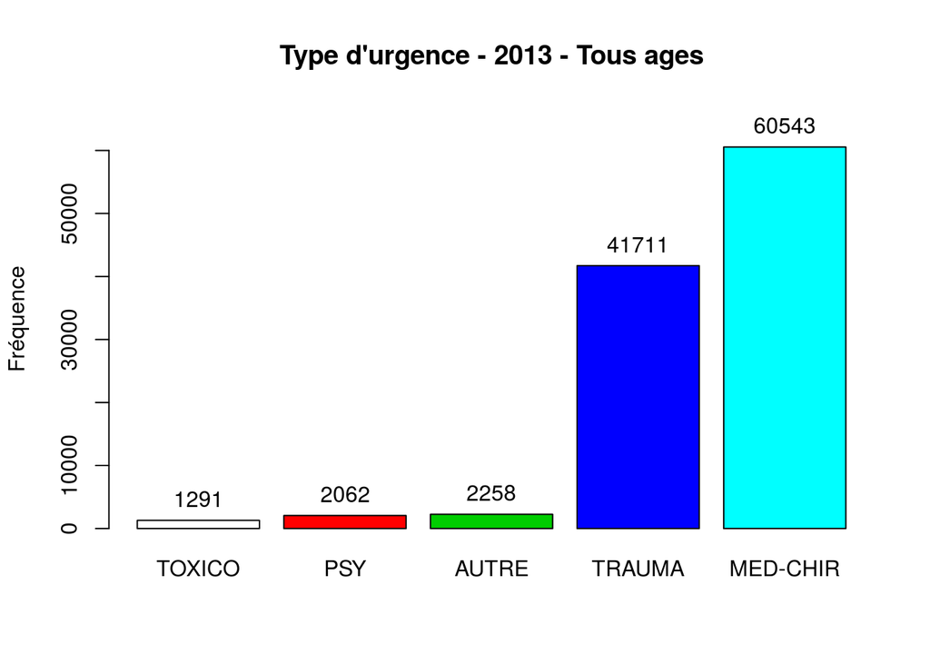

```
## greg2013$Code.Type.Urgences :
##          Frequency Percent Cum. percent
## TOXICO        1291     1.2          1.2
## PSY           2062     1.9          3.1
## AUTRE         2258     2.1          5.2
## TRAUMA       41711    38.7         43.9
## MED-CHIR     60543    56.1        100.0
##   Total     107865   100.0        100.0
```

```r
library(epicalc)

# récupère le fichier des regroupement de l'ORUMIP
if(as.character(Sys.info()["nodename"]) == "MacBook-Air-de-JCB.local")
file.reg <- "~/Documents/FEDORU/Codes_regroupement_ORUMIP/Regroupements ORUMiP Thésaurus SFMU.csv" else
file.reg <- "~/Documents/Resural/FEDORU/Codes_regroupement_ORUMIP/Regroupement_ORUMIP/Regroupements ORUMiP Thésaurus SFMU.csv"
reg <- read.csv(file.reg, skip = 1)
reg <- reg[, 1:8] # on ne garde que les 8 premières colonnes

# type d'urgences, tous ages confondus pour 2013 et 2014
greg2013 <- merge(rpu2013, reg, by.x = "DP", by.y = "CIM10", all.x)
greg2014 <- merge(rpu2014, reg, by.x = "DP", by.y = "CIM10", all.x)

tab1(greg2013$Code.Type.Urgences, sort.group = "increasing", main = "Type d'urgence - 2013 - Tous ages", ylab = "Fréquence")
```

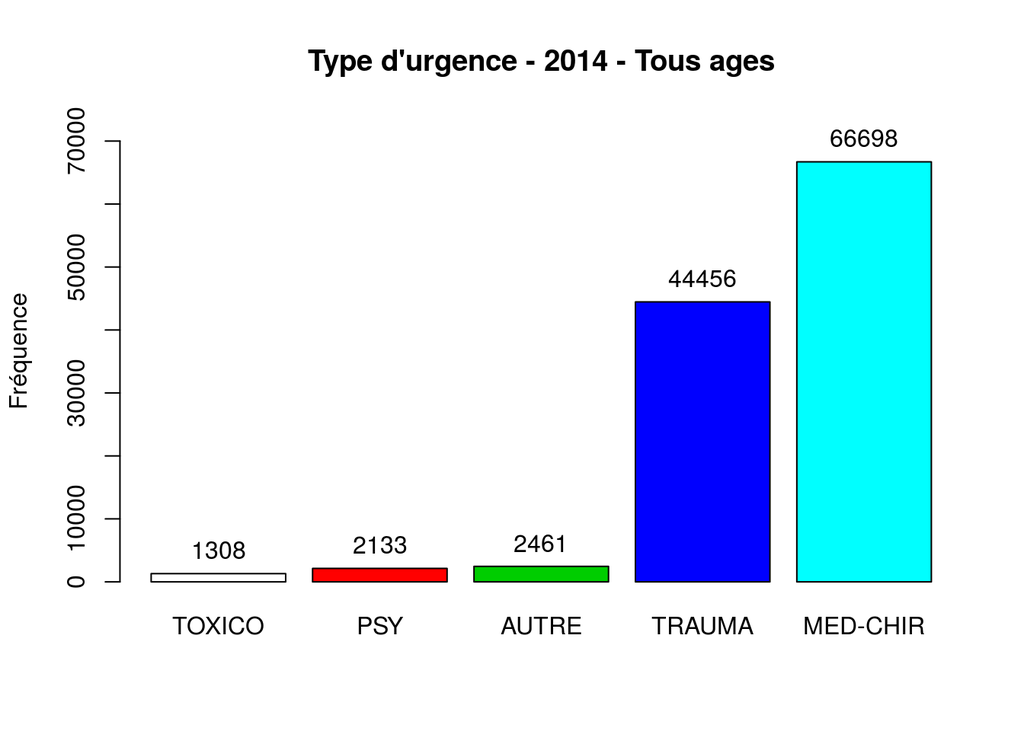

```
## greg2014$Code.Type.Urgences :
##          Frequency Percent Cum. percent
## TOXICO        1308     1.1          1.1
## PSY           2133     1.8          2.9
## AUTRE         2461     2.1          5.0
## TRAUMA       44456    38.0         43.0
## MED-CHIR     66698    57.0        100.0
##   Total     117056   100.0        100.0
```

```r
tab1(greg2014$Code.Type.Urgences, sort.group = "increasing", main = "Type d'urgence - 2014 - Tous ages", ylab = "Fréquence")
```

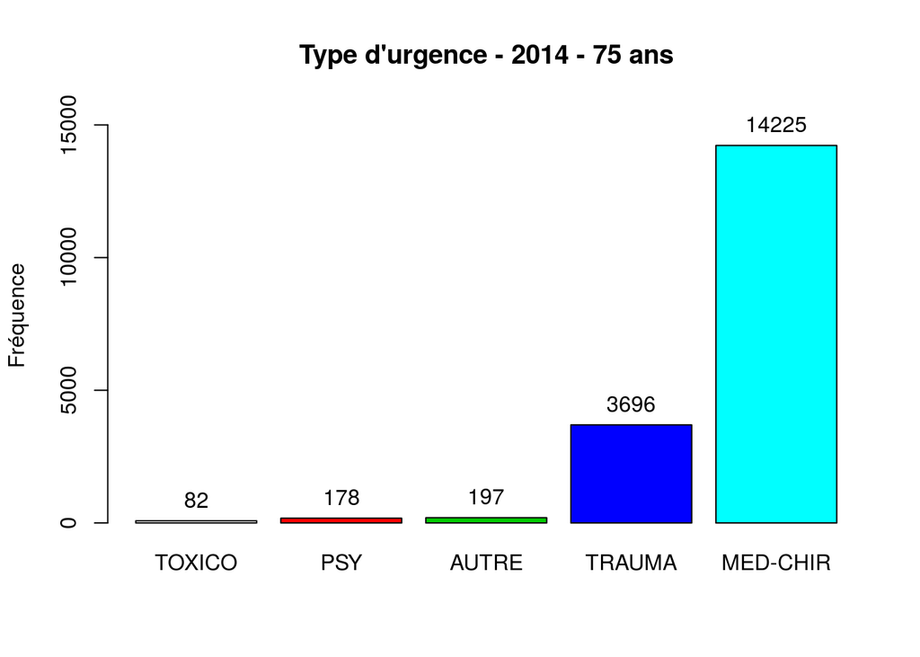

```
## greg2014.75$Code.Type.Urgences :
##          Frequency Percent Cum. percent
## TOXICO          82     0.4          0.4
## PSY            178     1.0          1.4
## AUTRE          197     1.1          2.5
## TRAUMA        3696    20.1         22.6
## MED-CHIR     14225    77.4        100.0
##   Total      18378   100.0        100.0
```

```r
# type d'urgences, pour les 75 ans et plus pour 2013 et 2014
rpu2013.75 <- rpu2013[rpu2013$AGE > 74,]
rpu2014.75 <- rpu2014[rpu2014$AGE > 74,]

greg2013.75 <- merge(rpu2013.75, reg, by.x = "DP", by.y = "CIM10", all.x)
greg2014.75 <- merge(rpu2014.75, reg, by.x = "DP", by.y = "CIM10", all.x)

tab1(greg2014.75$Code.Type.Urgences, sort.group = "increasing", main = "Type d'urgence - 2014 - 75 ans", ylab = "Fréquence")
```

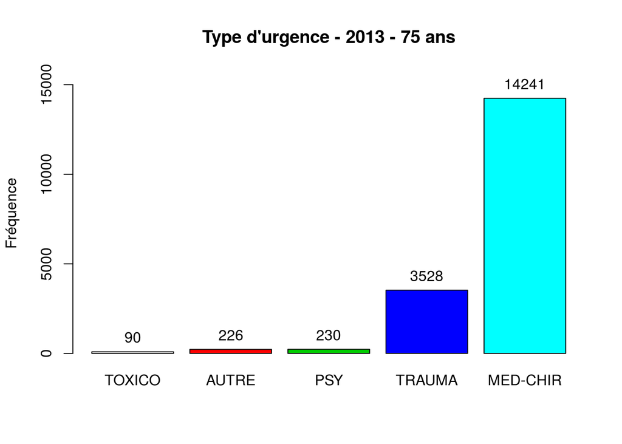

```
## greg2013.75$Code.Type.Urgences :
##          Frequency Percent Cum. percent
## TOXICO          90     0.5          0.5
## AUTRE          226     1.2          1.7
## PSY            230     1.3          3.0
## TRAUMA        3528    19.3         22.2
## MED-CHIR     14241    77.8        100.0
##   Total      18315   100.0        100.0
```

```r
tab1(greg2013.75$Code.Type.Urgences, sort.group = "increasing", main = "Type d'urgence - 2013 - 75 ans", ylab = "Fréquence")
```